# Red Wine Quality Analysis

# Which chemical properties influence the quality of red wines?

## Introduction

The tidy data set contains 1,599 red wines with 11 variables on the chemical properties of the wine. At least 3 wine experts rated the quality of each wine, providing a rating between 0 (very bad) and 10 (very excellent).

- 1599 records
- 11 chemical properties
- quality rating: 0 - 10

## Exploration of Data

### Load libraries

```r
library(GGally, ggplot2)
library(gridExtra)
library(RColorBrewer)
library(dplyr)
library(memisc) #Linear Regression: mtable
```

### Load data

```r
getwd()
```

```
## [1] "C:/Users/linjing/udacity-git-course/p6_wine_quality"
```

```r
list.files()
```

```
## [1] "README.md"             "red_wine_quality.html" "red_wine_quality.rmd"
## [4] "wineQualityReds.csv"
```

```r
df <- read.csv('wineQualityReds.csv')
head(df)
```

```
##   X fixed.acidity volatile.acidity citric.acid residual.sugar chlorides
## 1 1           7.4             0.70        0.00            1.9     0.076
## 2 2           7.8             0.88        0.00            2.6     0.098
## 3 3           7.8             0.76        0.04            2.3     0.092
## 4 4          11.2             0.28        0.56            1.9     0.075
## 5 5           7.4             0.70        0.00            1.9     0.076
## 6 6           7.4             0.66        0.00            1.8     0.075
##   free.sulfur.dioxide total.sulfur.dioxide density   pH sulphates alcohol
## 1                  11                   34  0.9978 3.51      0.56     9.4
## 2                  25                   67  0.9968 3.20      0.68     9.8
## 3                  15                   54  0.9970 3.26      0.65     9.8
## 4                  17                   60  0.9980 3.16      0.58     9.8
## 5                  11                   34  0.9978 3.51      0.56     9.4
## 6                  13                   40  0.9978 3.51      0.56     9.4
##   quality
## 1       5
## 2       5
## 3       5
## 4       6
## 5       5
## 6       5
```

```r
str(df)
```

```
## 'data.frame':    1599 obs. of  13 variables:
##  $ X                   : int  1 2 3 4 5 6 7 8 9 10 ...
##  $ fixed.acidity       : num  7.4 7.8 7.8 11.2 7.4 7.4 7.9 7.3 7.8 7.5 ...
##  $ volatile.acidity    : num  0.7 0.88 0.76 0.28 0.7 0.66 0.6 0.65 0.58 0.5 ...
##  $ citric.acid         : num  0 0 0.04 0.56 0 0 0.06 0 0.02 0.36 ...
##  $ residual.sugar      : num  1.9 2.6 2.3 1.9 1.9 1.8 1.6 1.2 2 6.1 ...
##  $ chlorides           : num  0.076 0.098 0.092 0.075 0.076 0.075 0.069 0.065 0.073 0.071 ...
##  $ free.sulfur.dioxide : num  11 25 15 17 11 13 15 15 9 17 ...
##  $ total.sulfur.dioxide: num  34 67 54 60 34 40 59 21 18 102 ...
##  $ density             : num  0.998 0.997 0.997 0.998 0.998 ...
##  $ pH                  : num  3.51 3.2 3.26 3.16 3.51 3.51 3.3 3.39 3.36 3.35 ...
##  $ sulphates           : num  0.56 0.68 0.65 0.58 0.56 0.56 0.46 0.47 0.57 0.8 ...
##  $ alcohol             : num  9.4 9.8 9.8 9.8 9.4 9.4 9.4 10 9.5 10.5 ...
##  $ quality             : int  5 5 5 6 5 5 5 7 7 5 ...
```

### Scatterplot Matrixes

```r
theme_set(theme_minimal(20))

set.seed(1000)
df_s <- df[, (2:13)]
names(df_s)
```

```
##  [1] "fixed.acidity"        "volatile.acidity"     "citric.acid"
##  [4] "residual.sugar"       "chlorides"            "free.sulfur.dioxide"
##  [7] "total.sulfur.dioxide" "density"              "pH"
## [10] "sulphates"            "alcohol"              "quality"
```

[figure not shown]

```r
ggpairs(df_s[sample.int(nrow(df_s), 1000),])
```

### Quality

```r
table(df$quality)
```

```
##
##   3   4   5   6   7   8
##  10  53 681 638 199  18
```

```r
summary(df$quality)
```

```
##    Min. 1st Qu.  Median    Mean 3rd Qu.    Max.
##   3.000   5.000   6.000   5.636   6.000   8.000
```

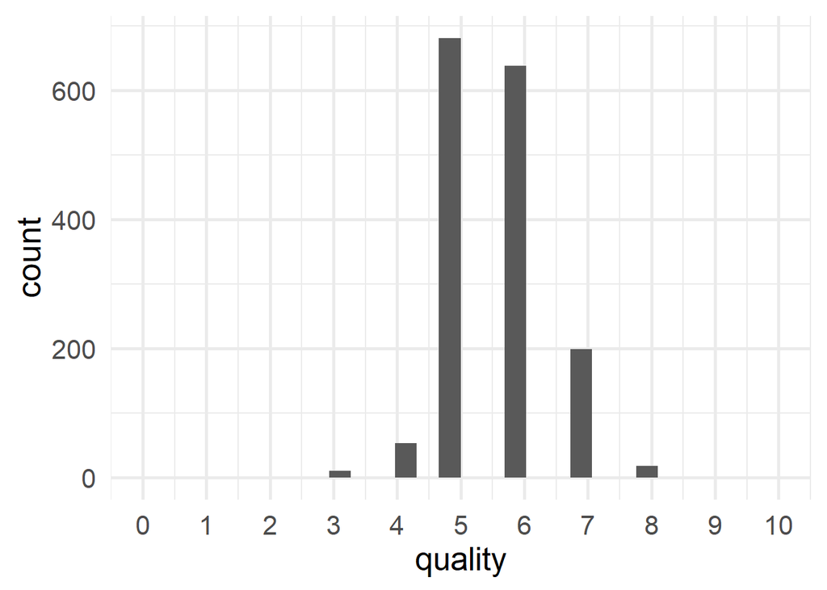

```r
ggplot(aes(x=quality, y = ..count..), data =df) +
  geom_histogram()+
  scale_x_continuous(limits = c(0,10),
                     breaks = seq(0, 10,1))
```

### fixed.acidity

```r
summary(df$fixed.acidity)
```

```
##    Min. 1st Qu.  Median    Mean 3rd Qu.    Max.
##    4.60    7.10    7.90    8.32    9.20   15.90
```

#### fixed_acidity: frequent polygone

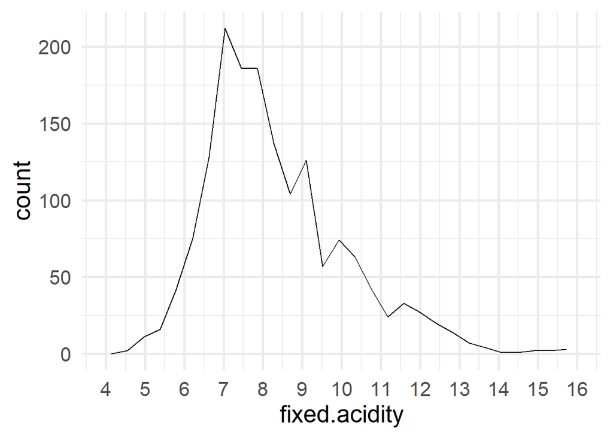

```r
ggplot(aes(x=fixed.acidity), data =df) +
  geom_freqpoly()+
  scale_x_continuous(limits = c(4,16),
                     breaks = seq(4, 16, 1))
```

#### fixed_acidity: log10, sqrt

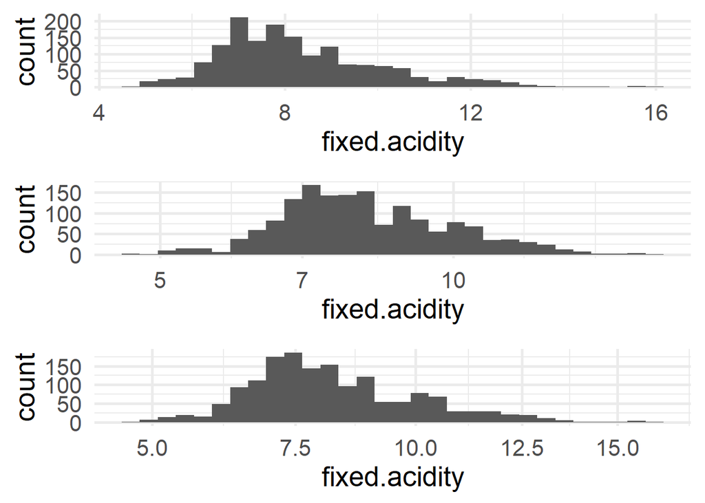

```r
fixed_acidity_p1 <- ggplot(aes(x=fixed.acidity), data= df) + geom_histogram()
fixed_acidity_p2 <- fixed_acidity_p1 + scale_x_log10()
fixed_acidity_p3 <- fixed_acidity_p1 + scale_x_sqrt()

grid.arrange(fixed_acidity_p1, fixed_acidity_p2, fixed_acidity_p3, ncol=1)
```

#### fixed.acidity(log10) & Quality

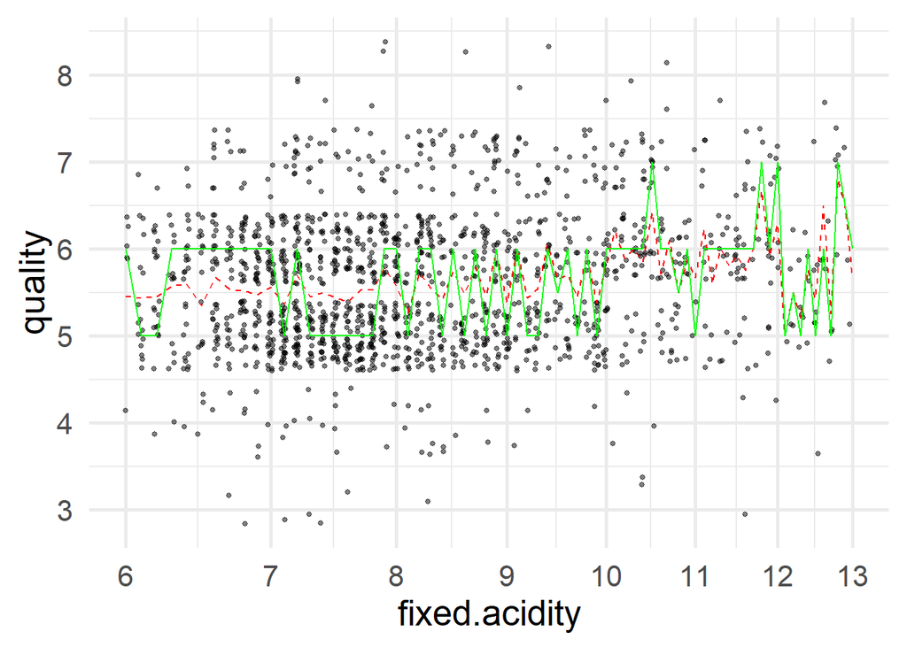

```r
ggplot(aes(x=fixed.acidity, y=quality),data=df)+
  geom_point(alpha = 0.5, size = 1, position = 'jitter')+
  scale_x_continuous(trans="log10",
                     limits = c(6,13),
                     breaks = seq(6,13,1))+
  scale_y_continuous() +
  geom_line(stat='summary', fun.y=mean, linetype=2, color='red')+
  geom_line(stat='summary', fun.y=quantile, fun.args=list(probs=.5),linetype=1, color='green')
```

#### fixed.acidity & Quality: Correlation (0.1140837)

```r
with(df,cor.test(fixed.acidity, quality, method = "spearman"))
```

```
##
##  Spearman's rank correlation rho
##
## data:  fixed.acidity and quality
## S = 603650000, p-value = 4.801e-06
## alternative hypothesis: true rho is not equal to 0
## sample estimates:
##       rho
## 0.1140837
```

### volatile.acidity

```r
summary(df$volatile.acidity)
```

```
##    Min. 1st Qu.  Median    Mean 3rd Qu.    Max.
##  0.1200  0.3900  0.5200  0.5278  0.6400  1.5800
```

#### volatile.acidity: frequent polygone

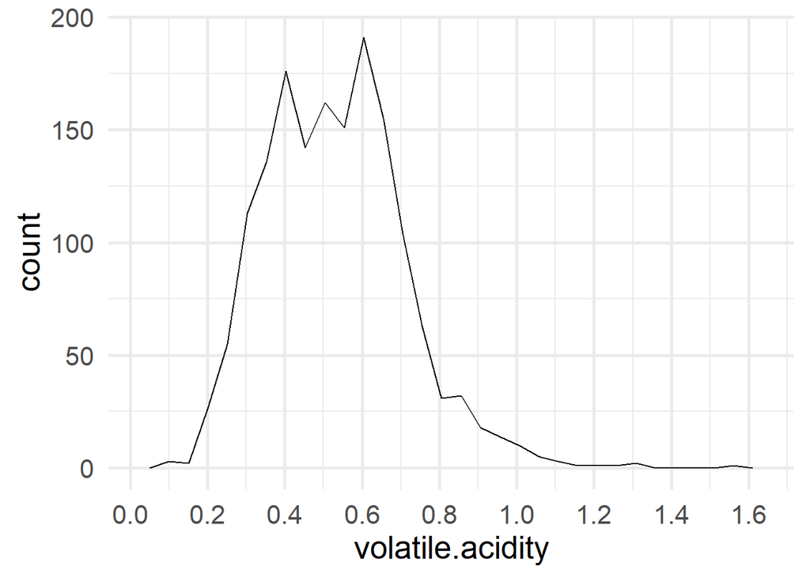

```r
ggplot(aes(x=volatile.acidity), data =df) +
  geom_freqpoly()+
  scale_x_continuous(breaks = seq(0, 1.6, 0.2))
```

#### volatile.acidity: log10, sqrt

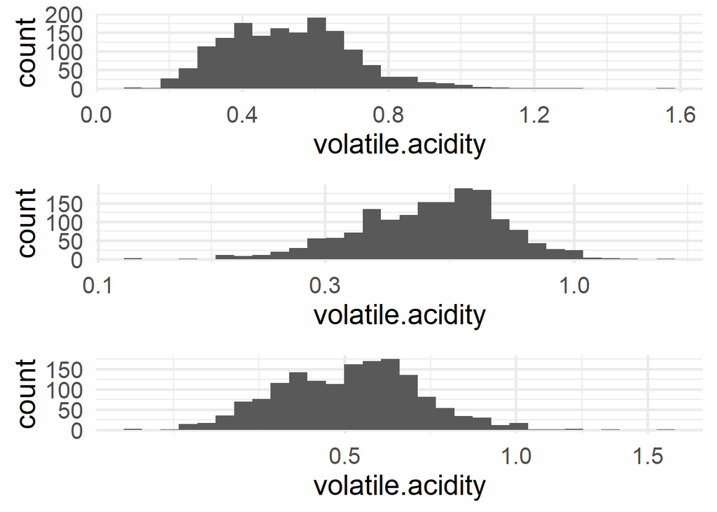

```r
volatile.acidity_p1 <- ggplot(aes(x=volatile.acidity), data= df) + geom_histogram()
volatile.acidity_p2 <- volatile.acidity_p1 + scale_x_log10()
volatile.acidity_p3 <- volatile.acidity_p1 + scale_x_sqrt()

grid.arrange(volatile.acidity_p1, volatile.acidity_p2, volatile.acidity_p3, ncol=1)
```

#### volatile.acidity & quality

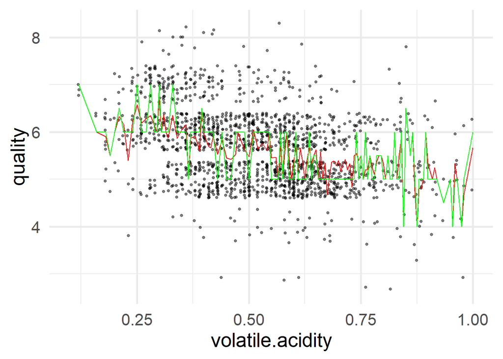

```r
ggplot(aes(x=volatile.acidity, y=quality),data=df)+
  geom_point(alpha = 0.5, size = 1, position = 'jitter')+
  scale_x_continuous(limits = c(0.1,1))+
  geom_line(stat='summary', fun.y=mean, linetype=1, color='red')+
  geom_line(stat='summary', fun.y=quantile, fun.args=list(probs=.5),linetype=1, color='green')
```

#### volatile.acidity & quality: correlation (-0.3806465 < -0.3)

```r
with(df, cor.test(volatile.acidity, quality, method = "spearman"))
```

```
##
##  Spearman's rank correlation rho
##
## data:  volatile.acidity and quality
## S = 940750000, p-value < 2.2e-16
## alternative hypothesis: true rho is not equal to 0
## sample estimates:
##        rho
## -0.3806465
```

### citric.acid

```r
summary(df$citric.acid)
```

```
##    Min. 1st Qu.  Median    Mean 3rd Qu.    Max.
##   0.000   0.090   0.260   0.271   0.420   1.000
```

#### citric.acid: frequent polygone

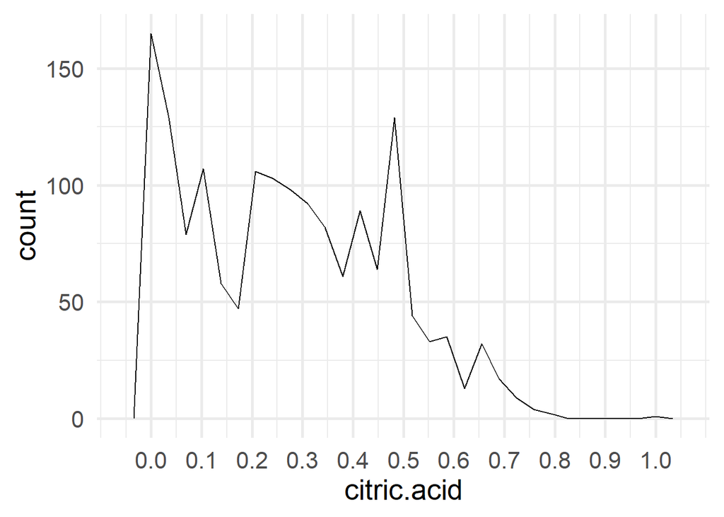

```r
ggplot(aes(x=citric.acid), data =df) +
  geom_freqpoly()+
  scale_x_continuous(breaks = seq(0, 1, 0.1))
```

#### citric.acid: log10, sqrt

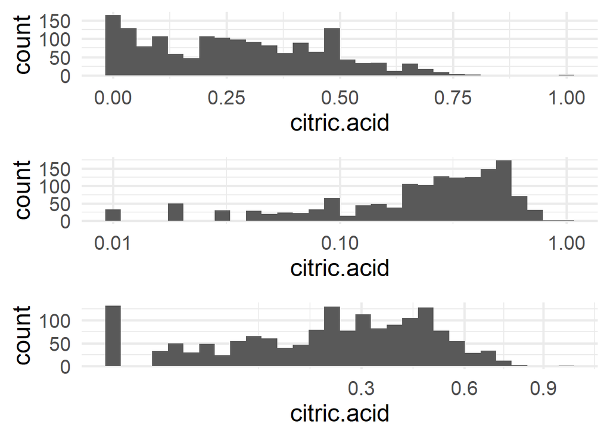

```r
citric.acid_p1 <- ggplot(aes(x=citric.acid), data= df) + geom_histogram()
citric.acid_p2 <- citric.acid_p1 + scale_x_log10()
citric.acid_p3 <- citric.acid_p1 + scale_x_sqrt()

grid.arrange(citric.acid_p1, citric.acid_p2, citric.acid_p3, ncol=1)
```

#### citric.acid(sqrt) & quality

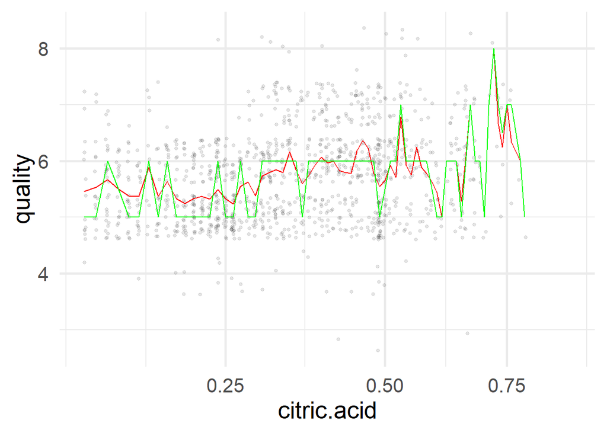

```r
ggplot(aes(x= citric.acid, y=quality),data=df)+
  geom_point(alpha = 0.1, size = 1, position = 'jitter')+
  scale_x_continuous(trans='sqrt',
                     limits = c(0.1, 0.9))+
  geom_line(stat='summary', fun.y=mean, linetype=1, color='red')+
  geom_line(stat='summary', fun.y=quantile, fun.args=list(probs=.5),linetype=1, color='green')
```

#### citric.acid & quality: correlation (0.2134809)

```r
with(df, cor.test(citric.acid, quality, method = "spearman"))
```

```
##
##  Spearman's rank correlation rho
##
## data:  citric.acid and quality
## S = 535920000, p-value < 2.2e-16
## alternative hypothesis: true rho is not equal to 0
## sample estimates:
##       rho
## 0.2134809
```

```r
with(
  subset(df, citric.acid>0),cor.test(citric.acid, quality, method = "spearman"))
```

```
##
##  Spearman's rank correlation rho
##
## data:  citric.acid and quality
## S = 413040000, p-value < 2.2e-16
## alternative hypothesis: true rho is not equal to 0
## sample estimates:
##       rho
## 0.2150318
```

### residual.sugar

```r
summary(df$residual.sugar)
```

```
##    Min. 1st Qu.  Median    Mean 3rd Qu.    Max.
##   0.900   1.900   2.200   2.539   2.600  15.500
```

#### residual.sugar: frequent polygone

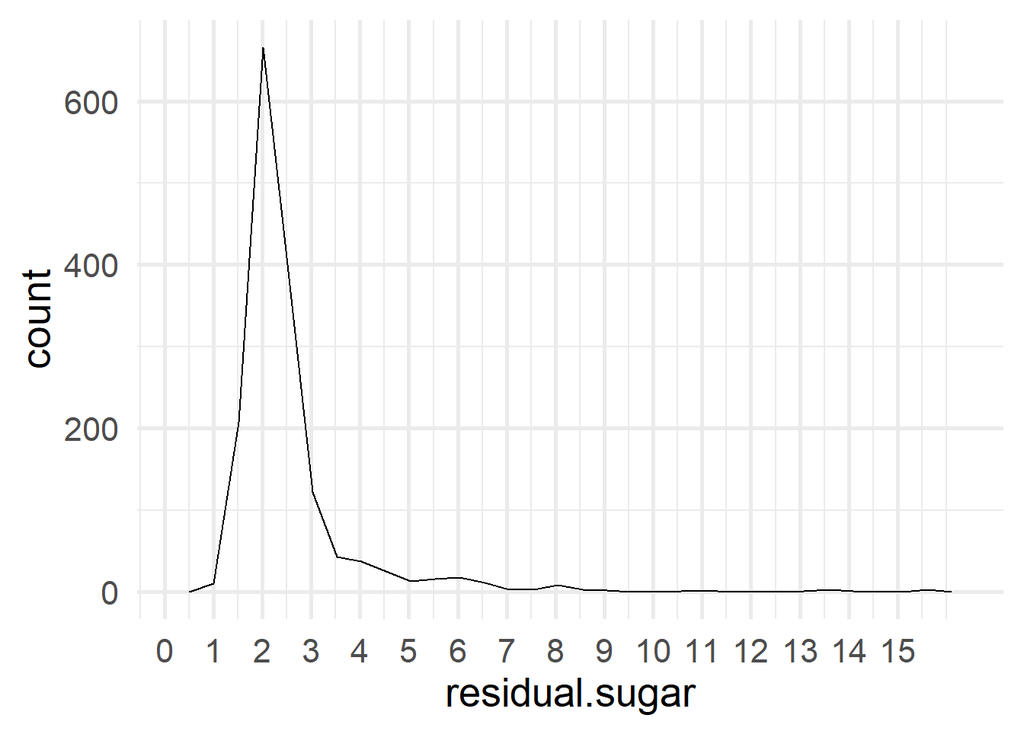

```r
ggplot(aes(x=residual.sugar), data =df) +
  geom_freqpoly()+
  scale_x_continuous(breaks = seq(0, 15, 1))
```

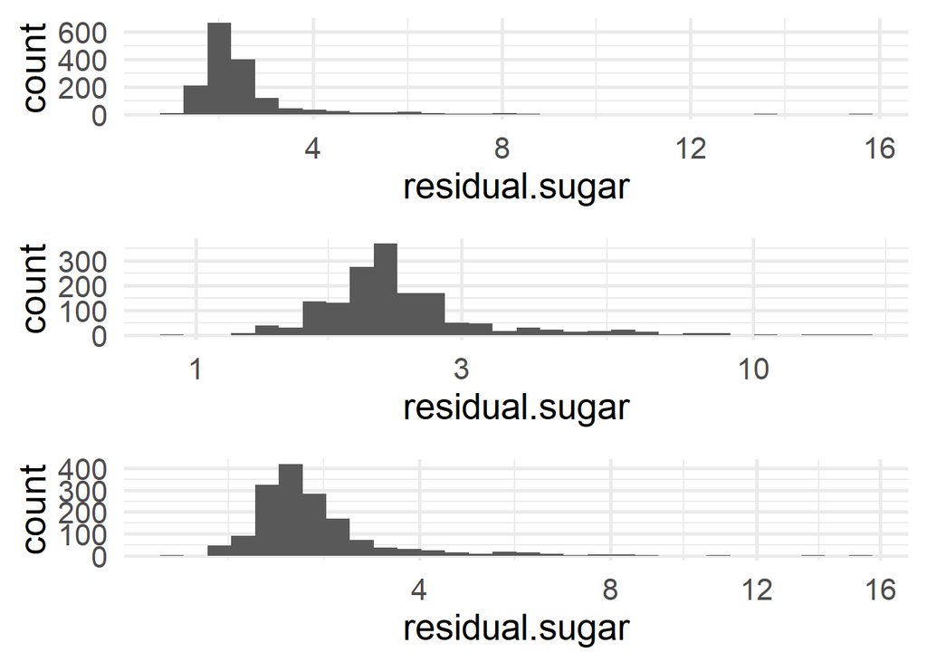

```r
residual.sugar_p1 <- ggplot(aes(x=residual.sugar), data= df) + geom_histogram()
residual.sugar_p2 <- residual.sugar_p1 + scale_x_log10()
residual.sugar_p3 <- residual.sugar_p1 + scale_x_sqrt()

grid.arrange(residual.sugar_p1, residual.sugar_p2, residual.sugar_p3, ncol=1)
```

#### residual.sugar & quality

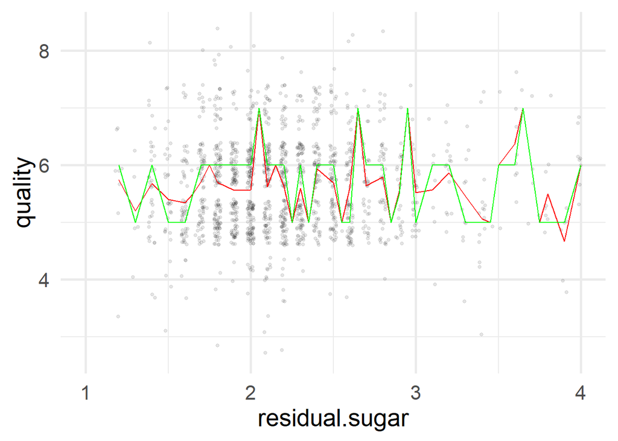

```r
ggplot(aes(x=residual.sugar, y=quality),data=df)+
  geom_point(alpha = 0.1, size = 1, position = 'jitter')+
  scale_x_continuous(limits = c(1,4))+
  geom_line(stat='summary', fun.y=mean, linetype=1, color='red')+
  geom_line(stat='summary', fun.y=quantile, fun.args=list(probs=.5),linetype=1, color='green')
```

#### residual.sugar & quality: correlation (0.03204817)

```r
with(df, cor.test(residual.sugar, quality, method = "spearman"))
```

```
##
##  Spearman's rank correlation rho
##
## data:  residual.sugar and quality
## S = 659550000, p-value = 0.2002
## alternative hypothesis: true rho is not equal to 0
## sample estimates:
##        rho
## 0.03204817
```

```r
with(
  subset(df, residual.sugar<4),cor.test(residual.sugar, quality, method = "spearman"))
```

```
##
##  Spearman's rank correlation rho
##
## data:  residual.sugar and quality
## S = 505810000, p-value = 0.2389
## alternative hypothesis: true rho is not equal to 0
## sample estimates:
##        rho
## 0.03081316
```

### chlorides (Cl)

```r
summary(df$chlorides)
```

```
##    Min. 1st Qu.  Median    Mean 3rd Qu.    Max.
## 0.01200 0.07000 0.07900 0.08747 0.09000 0.61100
```

#### chlorides: frequent polygone

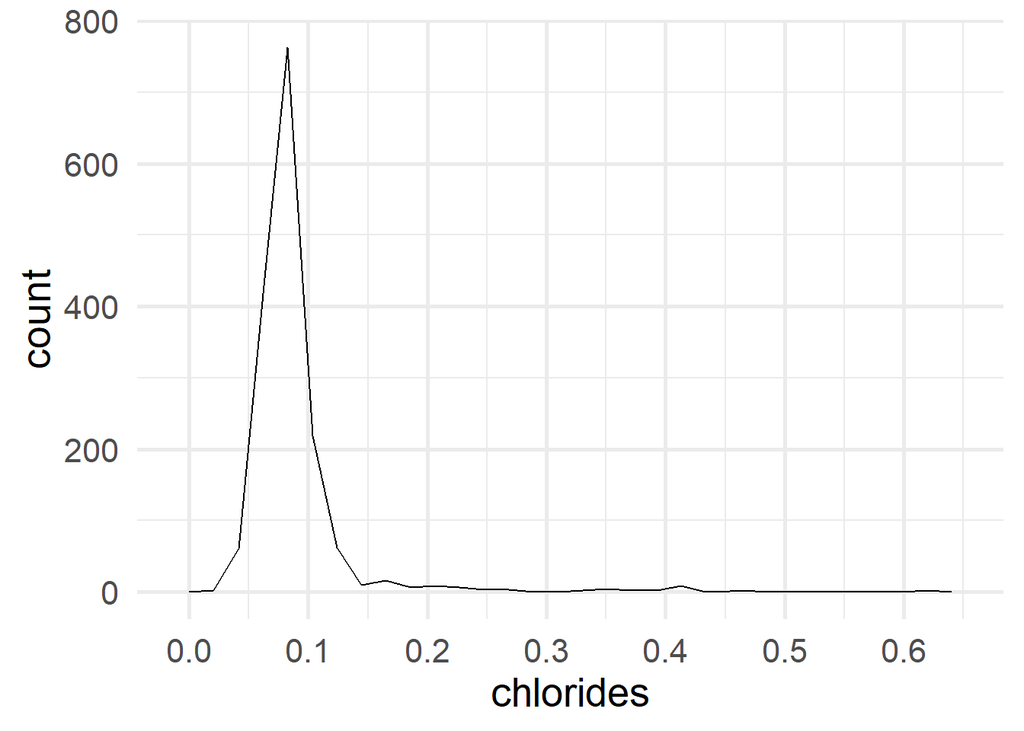

```r
ggplot(aes(x=chlorides), data =df) +
  geom_freqpoly()+
  scale_x_continuous(breaks = seq(0, 0.65, 0.1))
```

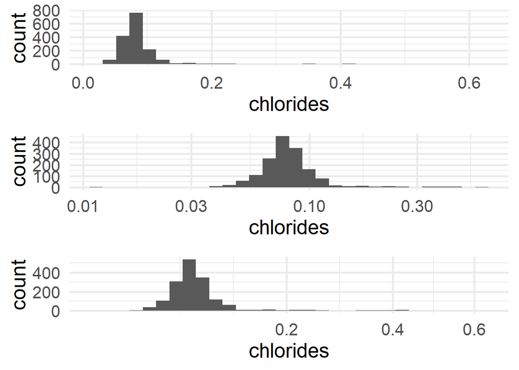

```r
chlorides_p1 <- ggplot(aes(x=chlorides), data= df) + geom_histogram()
chlorides_p2 <- chlorides_p1 + scale_x_log10()
chlorides_p3 <- chlorides_p1 + scale_x_sqrt()

grid.arrange(chlorides_p1, chlorides_p2, chlorides_p3, ncol=1)
```

#### chlorides(log10) & quality

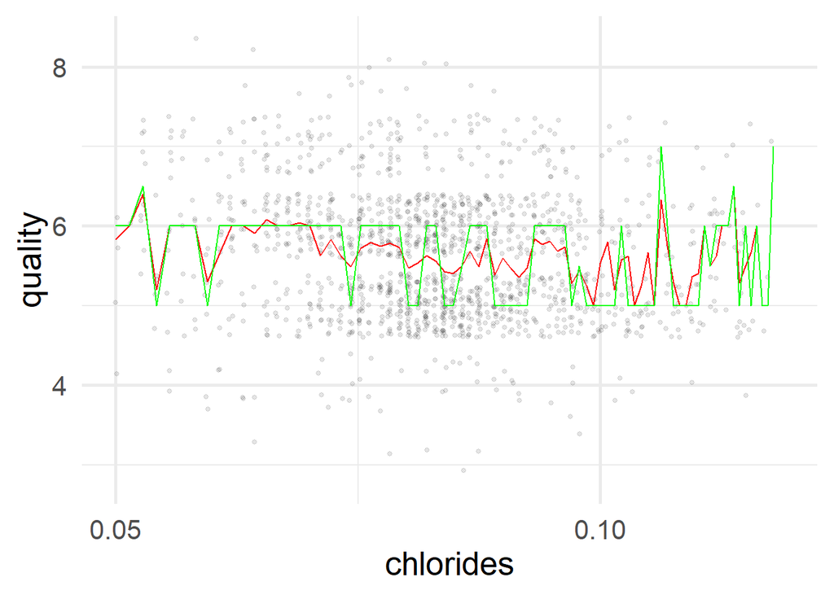

```r
ggplot(aes(x=chlorides, y=quality),data=df)+
  geom_point(alpha = 0.1, size = 1, position = 'jitter')+
  scale_x_continuous(trans = 'log10',
                     limits = c(0.05, 0.13),
                     breaks=seq(0.05, 0.13, 0.05))+
  geom_line(stat='summary', fun.y=mean, linetype=1, color='red')+
  geom_line(stat='summary', fun.y=quantile, fun.args=list(probs=.5),linetype=1, color='green')
```

```r
with(df, cor.test(chlorides, quality, method = "spearman"))
```

```
##
##  Spearman's rank correlation rho
##
## data:  chlorides and quality
## S = 810800000, p-value = 1.883e-14
## alternative hypothesis: true rho is not equal to 0
## sample estimates:
##        rho
## -0.1899223
```

```r
with(
  subset(df, chlorides<0.15),cor.test(chlorides, quality, method = "spearman"))
```

```
##
##  Spearman's rank correlation rho
##
## data:  chlorides and quality
## S = 708550000, p-value = 6.38e-13
## alternative hypothesis: true rho is not equal to 0
## sample estimates:
##        rho
## -0.1823558
```

### free.sulfur.dioxide

```r
summary(df$free.sulfur.dioxide)
```

```
##    Min. 1st Qu.  Median    Mean 3rd Qu.    Max.
##    1.00    7.00   14.00   15.87   21.00   72.00
```

#### free.sulfur.dioxide: frequent polygone

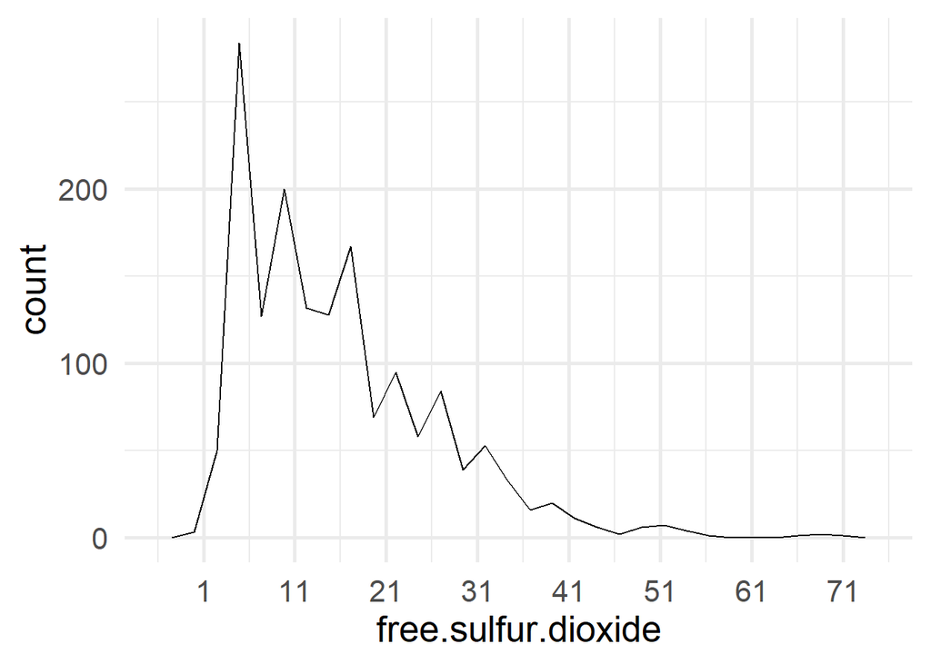

```r
ggplot(aes(x=free.sulfur.dioxide), data =df) +
  geom_freqpoly()+
  scale_x_continuous(breaks = seq(1, 72, 10))
```

#### free.sulfur.dioxide: log10, sqrt

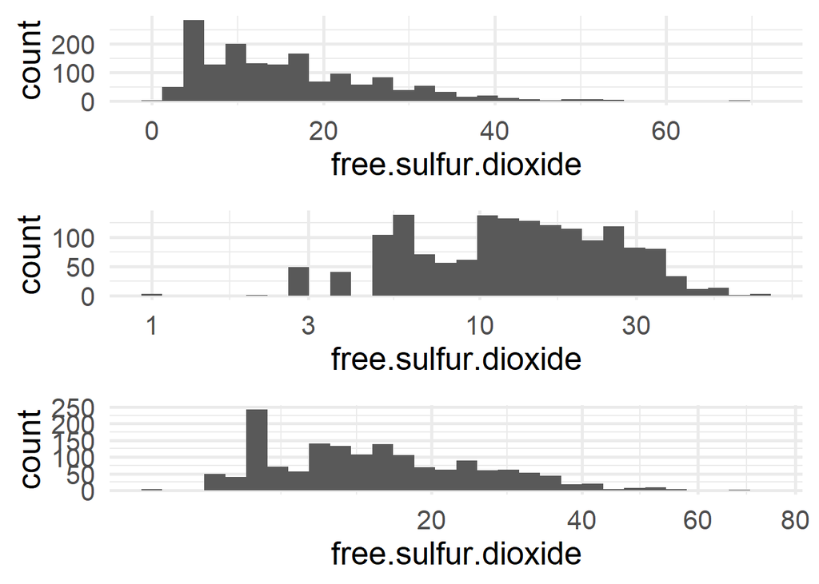

```r
free.sulfur.dioxide_p1 <- ggplot(aes(x=free.sulfur.dioxide), data= df) + geom_histogram()
free.sulfur.dioxide_p2 <- free.sulfur.dioxide_p1 + scale_x_log10()
free.sulfur.dioxide_p3 <- free.sulfur.dioxide_p1 + scale_x_sqrt()

grid.arrange(free.sulfur.dioxide_p1, free.sulfur.dioxide_p2, free.sulfur.dioxide_p3, ncol=1)
```

#### free.sulfur.dioxide(log10) & quality

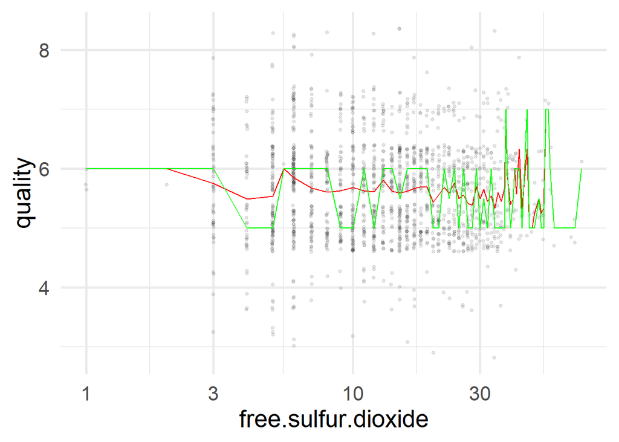

```r
ggplot(aes(x=free.sulfur.dioxide, y=quality),data=df)+
  geom_point(alpha = 0.1, size = 1, position = 'jitter')+
  scale_x_continuous(trans = 'log10')+
  geom_line(stat='summary', fun.y=mean, linetype=1, color='red')+
  geom_line(stat='summary', fun.y=quantile, fun.args=list(probs=.5),linetype=1, color='green')
```

#### free.sulfur.dioxide & quality: correlation (-0.05690065)

```r
with(df, cor.test(free.sulfur.dioxide, quality, method = "spearman"))
```

```
##
##  Spearman's rank correlation rho
##
## data:  free.sulfur.dioxide and quality
## S = 720160000, p-value = 0.02288
## alternative hypothesis: true rho is not equal to 0
## sample estimates:
##         rho
## -0.05690065
```

### total.sulfur.dioxide

```r
summary(df$total.sulfur.dioxide)
```

```
##    Min. 1st Qu.  Median    Mean 3rd Qu.    Max.
##    6.00   22.00   38.00   46.47   62.00  289.00
```

#### total.sulfur.dioxide: frequent polygone

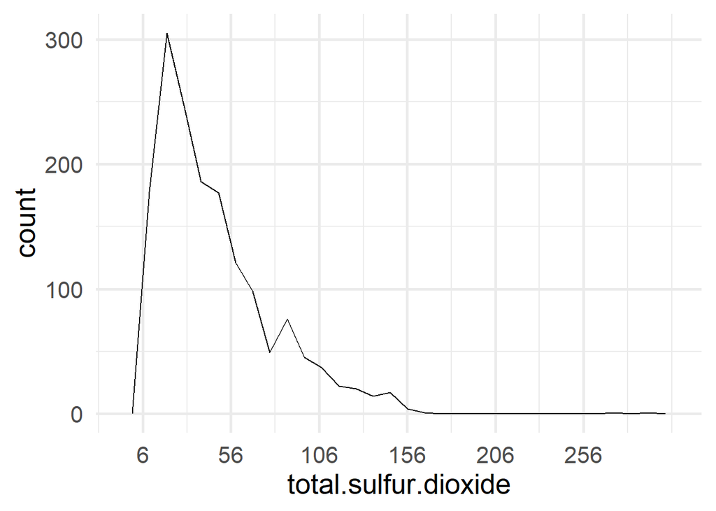

```r
ggplot(aes(x=total.sulfur.dioxide), data =df) +
  geom_freqpoly()+
  scale_x_continuous(breaks = seq(6, 289, 50))
```

#### total.sulfur.dioxide: log10, sqrt

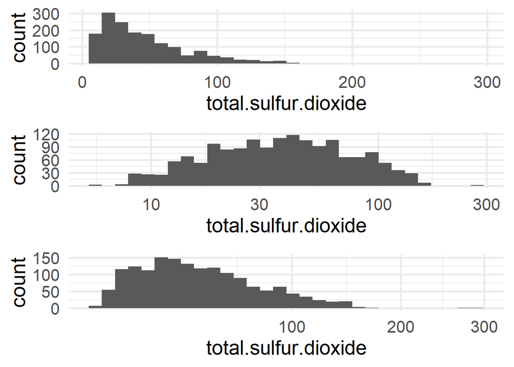

```r
total.sulfur.dioxide_p1 <- ggplot(aes(x=total.sulfur.dioxide), data= df) + geom_histogram()
total.sulfur.dioxide_p2 <- total.sulfur.dioxide_p1 + scale_x_log10()
total.sulfur.dioxide_p3 <- total.sulfur.dioxide_p1 + scale_x_sqrt()

grid.arrange(total.sulfur.dioxide_p1, total.sulfur.dioxide_p2, total.sulfur.dioxide_p3, ncol=1)
```

#### total.sulfur.dioxide(log10) & quality

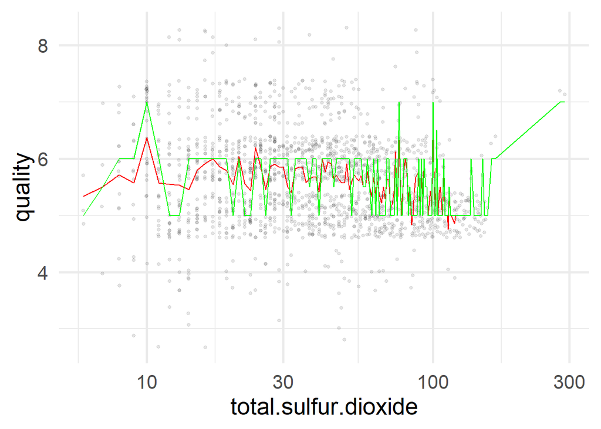

```r
ggplot(aes(x=total.sulfur.dioxide, y=quality),data=df)+
  geom_point(alpha = 0.1, size = 1, position = 'jitter')+
  scale_x_continuous(trans = 'log10')+
  geom_line(stat='summary', fun.y=mean, linetype=1, color='red')+
  geom_line(stat='summary', fun.y=quantile, fun.args=list(probs=.5),linetype=1, color='green')
```

#### total.sulfur.dioxide & quality: correlation (-0.1967351)

```r
with(df, cor.test(total.sulfur.dioxide, quality, method = "spearman"))
```

```
##
##  Spearman's rank correlation rho
##
## data:  total.sulfur.dioxide and quality
## S = 815440000, p-value = 2.046e-15
## alternative hypothesis: true rho is not equal to 0
## sample estimates:
##        rho
## -0.1967351
```

### density

```r
summary(df$density)
```

```
##    Min. 1st Qu.  Median    Mean 3rd Qu.    Max.
##  0.9901  0.9956  0.9968  0.9967  0.9978  1.0037
```

#### density: frequent polygone

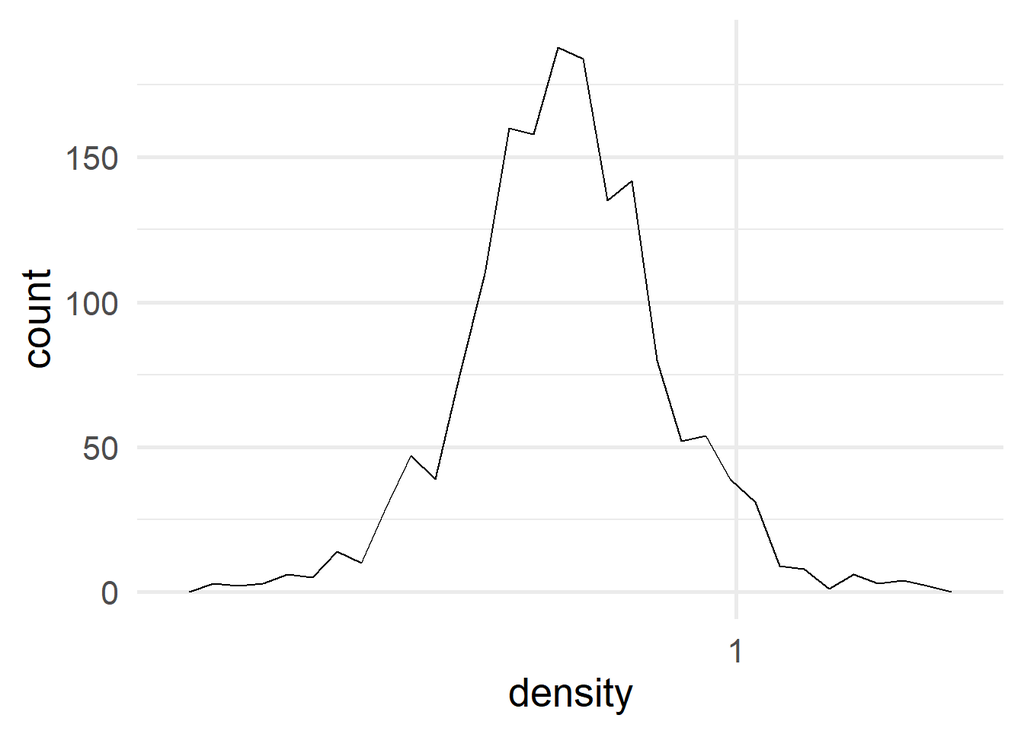

```r
ggplot(aes(x=density), data =df) +
  geom_freqpoly()+
  scale_x_continuous(breaks = seq(0.9, 1.1, 0.1))
```

#### density & quality

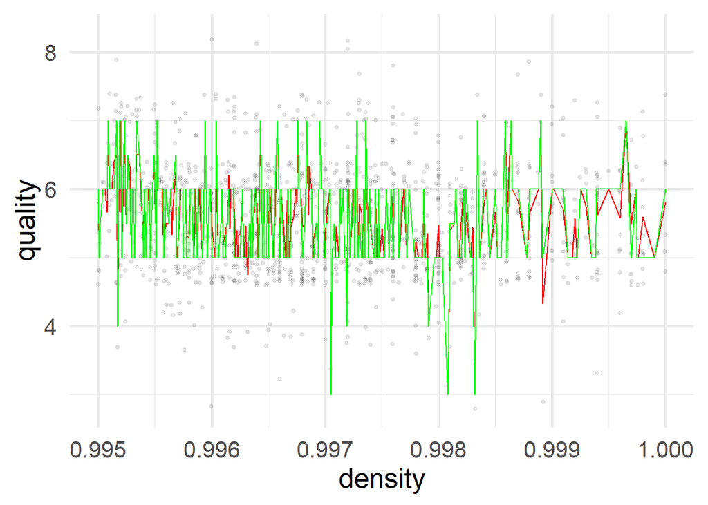

```r
ggplot(aes(x=density, y=quality),data=df)+
  geom_point(alpha = 0.1, size = 1, position = 'jitter')+
  scale_x_continuous(limits = c(0.995, 1))+
  geom_line(stat='summary', fun.y=mean, linetype=1, color='red')+
  geom_line(stat='summary', fun.y=quantile, fun.args=list(probs=.5),linetype=1, color='green')
```

#### density & quality: correlation (-0.1770741)

```r
with(df, cor.test(density, quality, method = "spearman"))
```

```
##
##  Spearman's rank correlation rho
##
## data:  density and quality
## S = 802040000, p-value = 9.918e-13
## alternative hypothesis: true rho is not equal to 0
## sample estimates:
##        rho
## -0.1770741
```

### pH

```r
summary(df$pH)
```

```
##    Min. 1st Qu.  Median    Mean 3rd Qu.    Max.
##   2.740   3.210   3.310   3.311   3.400   4.010
```

#### pH: frequent polygone

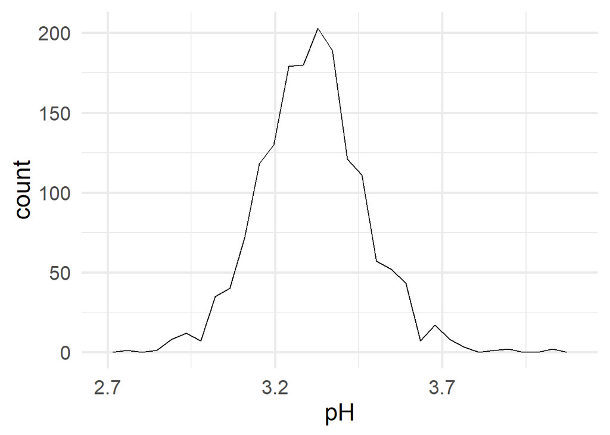

```r
ggplot(aes(x=pH), data =df) +
  geom_freqpoly()+
  scale_x_continuous(breaks = seq(2.7, 4.1, 0.5))
```

#### pH & quality

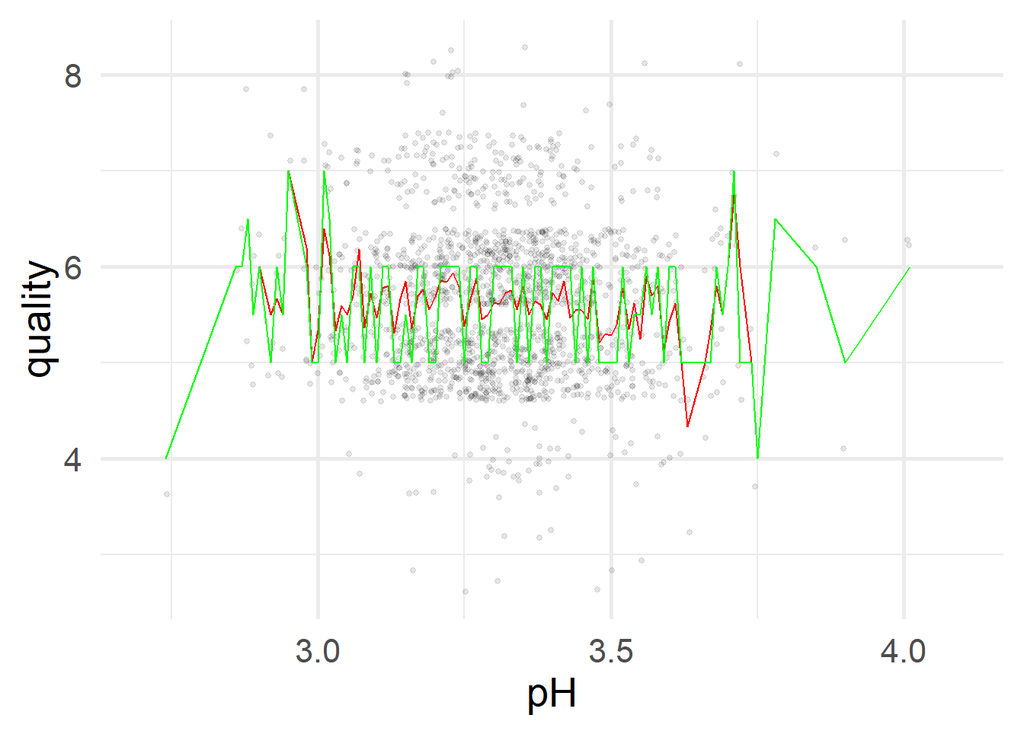

```r
ggplot(aes(x=pH, y=quality),data=df)+
  geom_point(alpha = 0.1, size = 1, position = 'jitter')+
  scale_x_continuous(limits = c(2.7, 4.1))+
  geom_line(stat='summary', fun.y=mean, linetype=1, color='red')+
  geom_line(stat='summary', fun.y=quantile, fun.args=list(probs=.5),linetype=1, color='green')
```

#### pH & quality: correlation (-0.04367193 )

```r
with(df, cor.test(pH, quality, method = "spearman"))
```

```
##
##  Spearman's rank correlation rho
##
## data:  pH and quality
## S = 711140000, p-value = 0.08085
## alternative hypothesis: true rho is not equal to 0
## sample estimates:
##         rho
## -0.04367193
```

```r
with(subset(df, pH >2.7 & pH <3.7),
     cor.test(pH, quality, method = "spearman"))
```

```
##
##  Spearman's rank correlation rho
##
## data:  pH and quality
## S = 693860000, p-value = 0.04062
## alternative hypothesis: true rho is not equal to 0
## sample estimates:
##         rho
## -0.05148223
```

### sulphates (SO4)

```r
summary(df$sulphates)
```

```
##    Min. 1st Qu.  Median    Mean 3rd Qu.    Max.
##  0.3300  0.5500  0.6200  0.6581  0.7300  2.0000
```

#### sulphates: frequent polygone

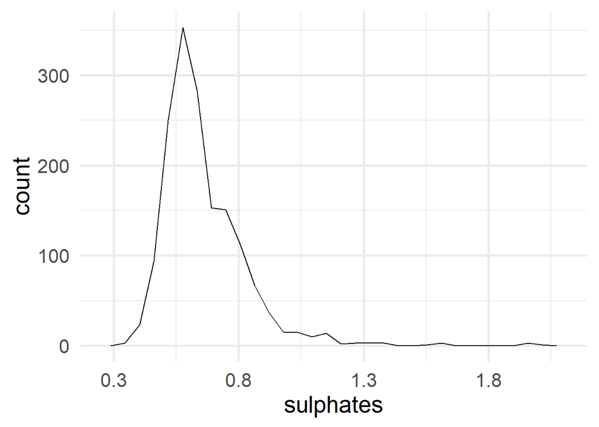

```r
ggplot(aes(x=sulphates), data =df) +
  geom_freqpoly()+
  scale_x_continuous(breaks = seq(0.3, 2, 0.5))
```

#### sulphates: log10, sqrt

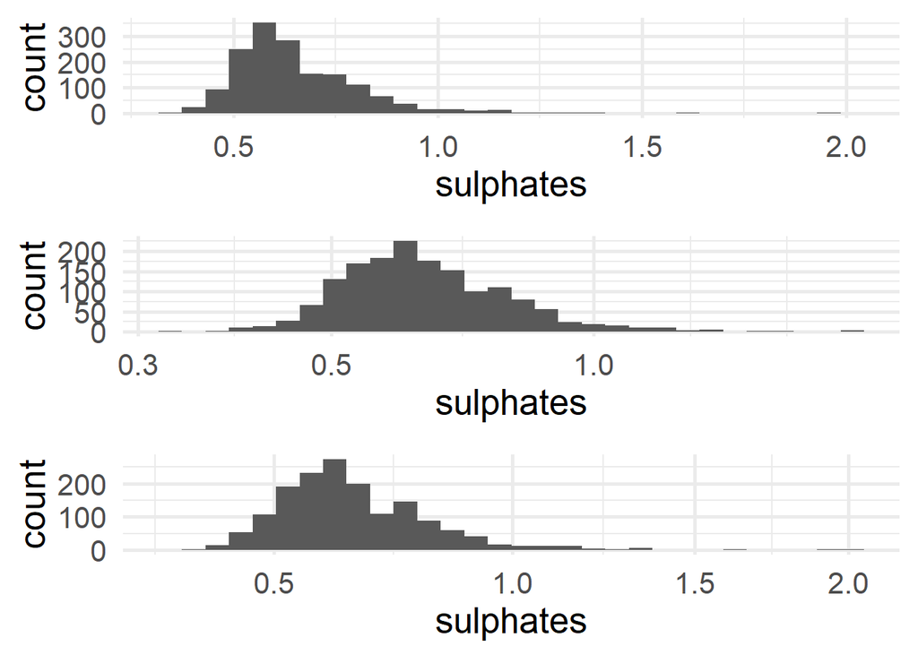

```r
sulphates_p1 <- ggplot(aes(x=sulphates), data= df) + geom_histogram()
sulphates_p2 <- sulphates_p1 + scale_x_log10()
sulphates_p3 <- sulphates_p1 + scale_x_sqrt()

grid.arrange(sulphates_p1, sulphates_p2, sulphates_p3, ncol=1)
```

#### sulphates(log10) & quality

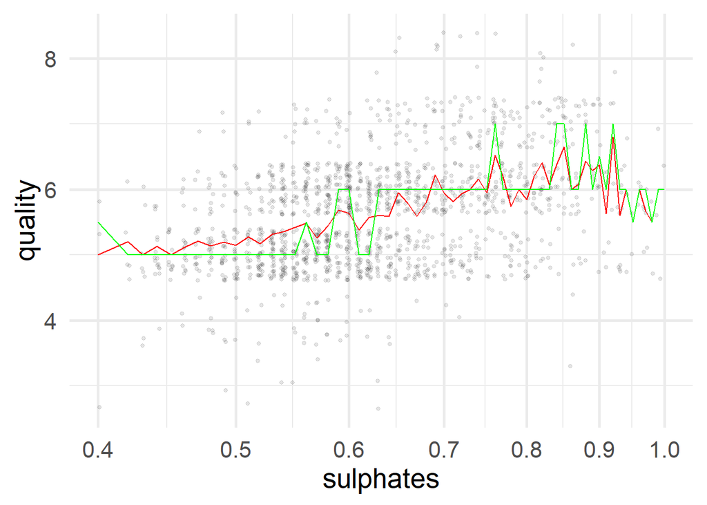

```r
ggplot(aes(x=sulphates, y=quality),data=df)+
  geom_point(alpha = 0.1, size = 1, position = 'jitter')+
  scale_x_continuous(trans='log10',
                     limits = c(0.4, 1.0),
                     breaks = seq(0.4, 1.0, 0.1))+
  geom_line(stat='summary', fun.y=mean, linetype=1, color='red')+
  geom_line(stat='summary', fun.y=quantile, fun.args=list(probs=.5),linetype=1, color='green')
```

#### sulphates & quality: correlation (0.3770602 > 0.3)

```r
with(df, cor.test(sulphates, quality, method = "spearman"))
```

```
##
##  Spearman's rank correlation rho
##
## data:  sulphates and quality
## S = 424460000, p-value < 2.2e-16
## alternative hypothesis: true rho is not equal to 0
## sample estimates:
##       rho
## 0.3770602
```

### alcohol

```r
summary(df$alcohol)
```

```
##    Min. 1st Qu.  Median    Mean 3rd Qu.    Max.
##    8.40    9.50   10.20   10.42   11.10   14.90
```

#### alcohol: frequent polygone

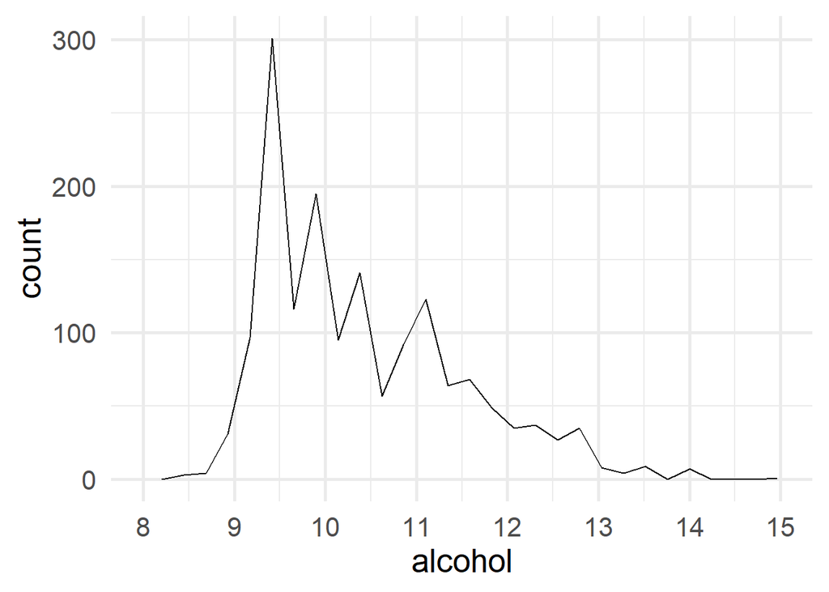

```r
ggplot(aes(x=alcohol), data =df) +
  geom_freqpoly()+
  scale_x_continuous(limits = c(8,15),
                     breaks = seq(8, 15, 1))
```

#### alcohol: log10, sqrt

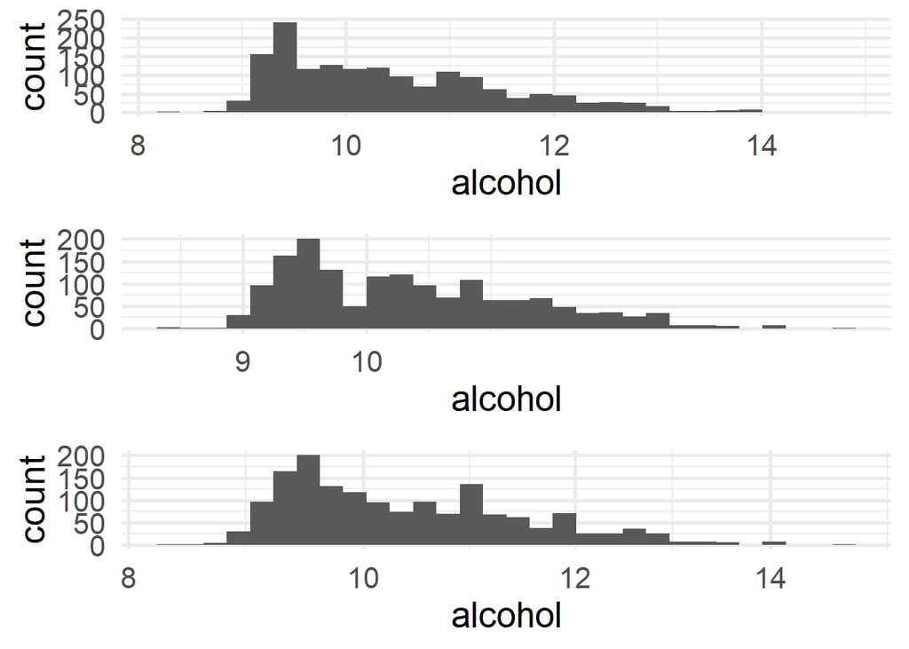

```r
alcohol_p1 <- ggplot(aes(x=alcohol), data= df) + geom_histogram()
alcohol_p2 <- alcohol_p1 + scale_x_log10()
alcohol_p3 <- alcohol_p1 + scale_x_sqrt()

grid.arrange(alcohol_p1, alcohol_p2, alcohol_p3, ncol=1)
```